# Correlation and Regression

## Correlation analysis

Consider a study, where we are interested in the relationship between two random variables.

### Bivariate normal distribution

We need to think of our data as a population of \( y_{i1} \) and \(y_{i2} \) pairs (a joint distribution of two variables or **a bivariate distribution**).

The bivariate normal distribution is defined by the mean and standard deviation of each variable and a parameter called the correlation coefficient, which measures the strength of the relationship between the two variables. A bivariate normal distribution implies that the individual variables are also normally distributed and also implies that any relationship between the two variables is a linear one.

```r
set.seed(12345)

    mean.x = 70  # mean of variable 1
    sd.x=3  # sd of variable 1
    mean.y=162 # mean of variable 2
    sd.y=14 # sd of variable 1
    r=0.55 # correlation between the two
    z1 <- rnorm(100)
    z2 <- rnorm(100)
    x1 <- sqrt(1-r^2)*sd.x*z1 + r*sd.x*z2 + mean.x
    y1 <- sd.y*z2 + mean.y

    r=0.90 # correlation between the two
    x2 <- sqrt(1-r^2)*sd.x*z1 + r*sd.x*z2 + mean.x
    y2 <- sd.y*z2 + mean.y

data_for_plot<- rbind(data.frame(x = x1, y = y1, r =0.55),
                       data.frame(x = x2, y = y2, r = 0.90))
```

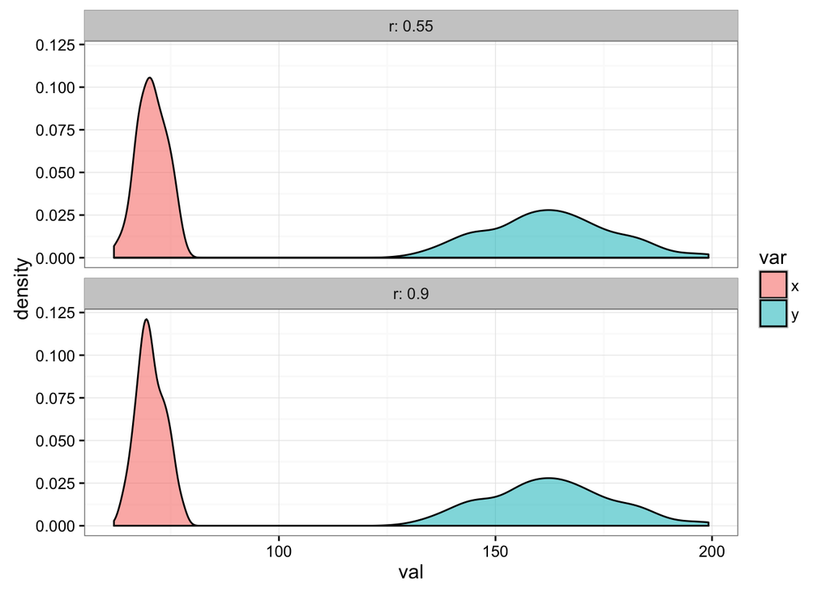

```r
data_for_plot %>%
  gather(var, val, x:y) %>%
  ggplot() +
  geom_density(aes(x=val, fill = var), alpha = 0.55) +
  facet_wrap(~r, ncol = 1,labeller = label_both) +
  theme_bw()
```

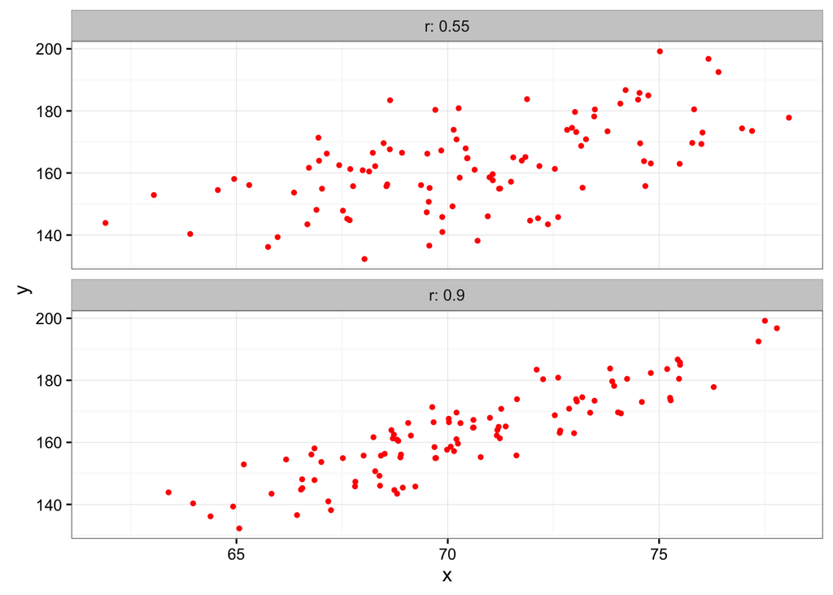

```r
ggplot(data=data_for_plot) +
  geom_point(aes(x = x, y = y), color = "red", size =1) +
  facet_wrap(~r, ncol = 1,labeller = label_both) +
  theme_bw()
```

### Covariance and correlation

Covariance is the linear relationship between two continuous variables.

#### Covariance

$$s_{Y1Y2} = \frac{\sum_{i =1}^n (y_{i1} - \bar{y_1})(y_{i2} - \bar{y_2})}{n-1}$$

```r
#Covariance
dev.x<- x1 - mean(x1)
dev.y<- y1 - mean(y1)

sum(dev.x * dev.y)/ (length(dev.x) - 1)
```

```
## [1] 27.74278
```

```r
cov(x1,y1)
```

```
## [1] 27.74278
```

One problem with covariance is that the absolute magnitude depends on the units of the two variables

```r
cov(x1,y1)
```

```
## [1] 27.74278
```

```r
cov(x1*1000,y1*100)
```

```
## [1] 2774278
```

### Pearson correlation

The covariance can be standardized by dividing by the standard deviations of the two variables so that the value range between -1 and +1. This is called the Pearson (product-moment) correlation.

$$s_{Y1Y2} = \frac{\sum_{i =1}^n (y_{i1} - \bar{y_1})(y_{i2} - \bar{y_2})}{\sqrt{\sum_{i =1}^n (y_{i1} - \bar{y_1})^2 \sum_{i =1}^n (y_{i2} - \bar{y_2})^2}}$$

The Pearson correlation measures the “strength” of the linear relationship between the two continuous variables.

```r
sum(dev.x * dev.y)/ (sqrt(sum(dev.x^2) * sum(dev.y^2)))
```

```
## [1] 0.5764552
```

```r
cor(x1,y1, method = "pearson")
```

```
## [1] 0.5764552
```

```r
cor.test(x1,y1, method = "pearson")
```

```
##
##  Pearson's product-moment correlation
##
## data:  x1 and y1
## t = 6.9837, df = 98, p-value = 3.472e-10
## alternative hypothesis: true correlation is not equal to 0
## 95 percent confidence interval:
##  0.4285615 0.6942644
## sample estimates:
##       cor
## 0.5764552
```

Remember up above when we generated `x1` and `y1` that we used a correlation value, `r`, of 0.55.

### Robust correlation (Spearman’s rank correlation)

We may have a situation where the joint distribution of our two variables is not bivariate normal.

- non-normality in either variable
- monotonic relationships that are not linear

```r
r_x1<-rank(x1)
r_y1<-rank(y1)

cor(r_x1, r_y1)
```

```
## [1] 0.5744134
```

```r
cor(x1, y1, method ="spearman")
```

```
## [1] 0.5744134
```

```r
# Kendalls tau is based on concordant and disconcordant pairs.  is more conservative than spearman
cor(x1, y1, method ="kendall")
```

```
## [1] 0.3967677
```

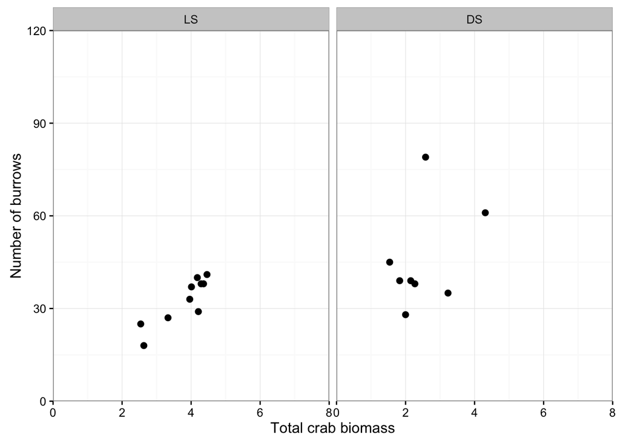

```r
crabs<-read_csv(getURL("https://raw.githubusercontent.com/chrischizinski/SNR_R_Group/master/data/ExperimentalDesignData/chpt5/green.csv"))

crabs$SITE<-factor(crabs$SITE, levels = c("LS","DS"))

ggplot(data = crabs) +
  geom_point(aes(x = TOTMASS, y = BURROWS), size = 2) +
  facet_wrap(~SITE, ncol = 2) +
  coord_cartesian(xlim = c(0,8), ylim = c(0, 120), expand = F) +
  scale_x_continuous(breaks = seq(0,8, by=2)) +
  labs(x = "Total crab biomass", y = "Number of burrows") +
  theme_bw()
```

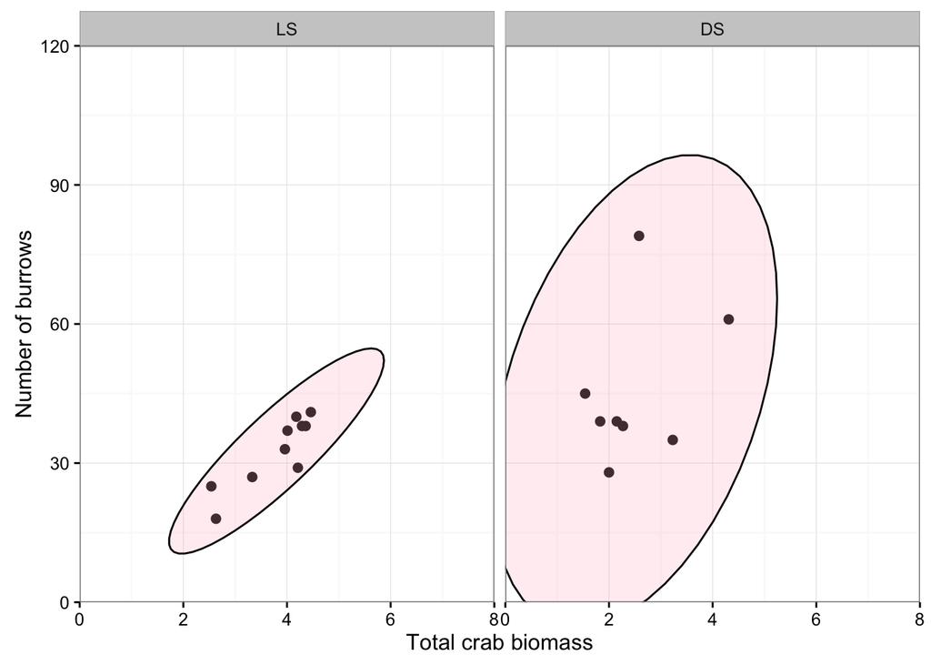

```r
p<-ggplot(data = crabs) +
  geom_point(aes(x = TOTMASS, y = BURROWS), size = 2) +
  stat_ellipse(geom = "polygon", aes(x = TOTMASS, y = BURROWS), type = "norm", level = 0.95, fill = "pink", alpha = 0.25, color = "black") +
  facet_wrap(~SITE, ncol = 2) +
  coord_cartesian(xlim = c(0,8), ylim = c(0, 120), expand = F) +
  scale_x_continuous(breaks = seq(0,8, by=2)) +
  labs(x = "Total crab biomass", y = "Number of burrows") +
  theme_bw()

p
```

```r
# library(MASS)
# dens1 <- kde2d(crabs$TOTMASS[crabs$SITE =="LS"], crabs$BURROWS[crabs$SITE =="LS"], n = 100, lims = c(0,8,0,120))
#
# densdf <- data.frame(expand.grid(TOTMASS = dens1$x, BURROWS =dens1$y), z = as.vector(dens1$z), SITE = "LS")

# library(ks)
# d<-crabs[,c("TOTMASS","BURROWS")]
# hscv1 <- Hscv(d)
# fhat <- ks::kde(d, H=hscv1, compute.cont=TRUE)
#
# densdf <- data.frame(expand.grid(TOTMASS = fhat[["eval.points"]][[1]], BURROWS =fhat[["eval.points"]][[2]]), z = as.vector(fhat[['estimate']]), SITE = "LS")
# d<-crabs[,c("TOTMASS","BURROWS")]
# getLevel <- function(x,y,prob=0.95) {
#     kk <- MASS::kde2d(x,y)
#     dx <- diff(kk$x[1:2])
#     dy <- diff(kk$y[1:2])
#     sz <- sort(kk$z)
#     c1 <- cumsum(sz) * dx * dy
#     approx(c1, sz, xout = 1 - prob)$y
# }
# L95 <- getLevel(crabs$TOTMASS[crabs$SITE=="LS"],crabs$BURROWS[crabs$SITE=="LS"])
#
# ggplot(data = crabs) +
#   # geom_point(aes(x = TOTMASS, y = BURROWS), size = 2) +
#   # stat_ellipse(geom = "polygon", aes(x = TOTMASS, y = BURROWS), type = "norm", level = 0.95, fill = "pink", alpha = 0.25, color = "black") +
#
#   geom_contour(data=densdf,aes(x = TOTMASS, y = BURROWS,z=z), breaks=L95, color="red")
#   geom_contour(data=densdf,aes(x = TOTMASS, y = BURROWS, z=z, breaks = L95)) +
#   facet_wrap(~SITE, ncol = 2) +
#   coord_cartesian(xlim = c(0,8), ylim = c(0, 120), expand = F) +
#   scale_x_continuous(breaks = seq(0,8, by=2)) +
#   labs(x = "Total crab biomass", y = "Number of burrows") +
#   theme_bw()
```